# LOH_H2O2_20160121_summary

e guven

January 22, 2016

2016 Jan 22, EG has started to contribute 0n *4c.2013Dec10,1030am-H2O2LOH.R 2013 Dec 9, using results from* 3b.2013Dec9.summarizeFitting.H2O2LOH.R

2013Nov25, use summarized results from _3.*R, which contains standard deviations.  
2008 CLS data uses M14, 2013H2O2 uses SGU57, so only 10 strains overlaps

Use 2013 fitting results and gnls reults 2013Nov14, use correlated regression Reverse L0 axis in plot, 2012 July 30

2012Feb25, Tg.vs.Tc ~ ln(R0) + G Partial correlations are all negative, what does this mean? Of couse, they should be negative correlations. Tg/Tc is a measure of ability to maintian recombiation rate during aging

```r
 rm( list = ls() );
 #setwd("~/github/LOH_H2O2_2016_perivously_forked/analysis")


 #Load 2013 H2O2-LOH results
 list.files(pattern="csv", path='output')
```

```
## [1] "LOHH2O2_all_20131127.csv"        "LOHH2O2_averaged20131210_v1.csv"
```

```r
 tb2 = read.csv("output/LOHH2O2_averaged20131210_v1.csv")

# Load previous LOH-CLS results, Qin Plos One 2008
# tb = read.table("summary.new.by.strain.csv", header=T, sep="\t");
 tb = read.table("021307.summary.by.strain.csv", header=T, sep="\t");
 tb.old = tb;
 labels = names( tb.old );
 tb = tb.old[, c("strain","ARLS","R0","G","CLS","Tc", "Tg","Tmmax","Tbmax", "Td", "Tdmax","TLmax","Lmax",
 "b.max", "b.min", "strains", "L0.all", "L0.small" , "Pbt0","Pb0.5t0", "Pbt0.b") ];
 tb$CLS.vs.Tc = tb$CLS / tb$Tc;
 tb$Tg.vs.Tc = tb$Tg / tb$Tc;
 tb$strain = as.character(tb$strain)
 tb.old = tb;
 tb = tb.old[1:13,] #remove rad52DD
 tb.test = tb[1:11,]

 summary(lm(Tg.vs.Tc ~ ARLS, data=tb.test)) #re-run the old results, just to double-check
```

```
##
## Call:
## lm(formula = Tg.vs.Tc ~ ARLS, data = tb.test)
##
## Residuals:
##      Min       1Q   Median       3Q      Max
## -0.28096 -0.10360  0.03093  0.13209  0.23406
##
## Coefficients:
##             Estimate Std. Error t value Pr(>|t|)
## (Intercept) -0.03702    0.41283  -0.090  0.93052
## ARLS         0.04439    0.01310   3.388  0.00803 **
## ---
## Signif. codes:  0 '***' 0.001 '**' 0.01 '*' 0.05 '.' 0.1 ' ' 1
##
## Residual standard error: 0.1857 on 9 degrees of freedom
## Multiple R-squared:  0.5605, Adjusted R-squared:  0.5117
## F-statistic: 11.48 on 1 and 9 DF,  p-value: 0.008026
```

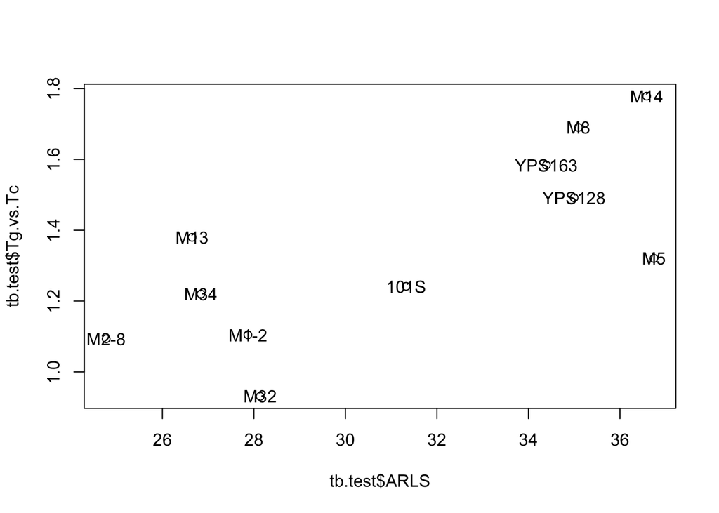

```r
 plot( tb.test$Tg.vs.Tc ~ tb.test$ARLS )
 text(tb.test$ARLS, tb.test$Tg.vs.Tc, tb.test$strains)
```

```r
 summary(lm( 1/Tg.vs.Tc ~ ARLS, data=tb.test)) #good, negative, p=0.012
```

```
##
## Call:
## lm(formula = 1/Tg.vs.Tc ~ ARLS, data = tb.test)
##
## Residuals:
##      Min       1Q   Median       3Q      Max
## -0.15828 -0.06543 -0.01532  0.04604  0.22840
##
## Coefficients:
##             Estimate Std. Error t value Pr(>|t|)
## (Intercept)  1.54881    0.25270   6.129 0.000173 ***
## ARLS        -0.02499    0.00802  -3.115 0.012408 *
## ---
## Signif. codes:  0 '***' 0.001 '**' 0.01 '*' 0.05 '.' 0.1 ' ' 1
##
## Residual standard error: 0.1137 on 9 degrees of freedom
## Multiple R-squared:  0.5189, Adjusted R-squared:  0.4654
## F-statistic: 9.706 on 1 and 9 DF,  p-value: 0.01241
```

```r
 #load exg06 data
 nat = read.table("062705.rls.cls.tab", sep="\t", header=T, colClasses=c("character", rep(NA,4)) );
```

merge tb and tb2

tb2$strain = tb2$strains #tb3a = merge(tb, tb2, by=‘strain’, all=T) tb3 = merge(tb, tb2, by=‘strain’) tb3 = tb3[ , -(grep(‘strains’, names(tb3))) ]

#remove BY4743, will increae p-value #tb3 = tb3[ tb3$strain != “BY4743”, ]

summary(lm(tb3$Cv.vs.Cb ~ tb3$ARLS)) #p 0.078 summary(lm(tb3$Cb.vs.Cv ~ tb3$ARLS)) #p 0.039

#summary(lm( tb3$ARLS ~ tb3$CvManu * tb3$CbManu ))

### regression analysis pTb = 1: length(tb3[1,]) names(pTb) = names(tb3) for( j in c(2:41) ) { #m = lm( tb3a[, j] ~ tb3a$ARLS, na.rm=T) m = lm( tb3[, j] ~ tb3$Cb.vs.Cv, na.rm=T) #m = lm( tb3a[, j] ~ tb3a$CvMean, na.rm=T) #m = lm( tb3a[, j] ~ tb3a$CbMean, na.rm=T) sm = summary(m) pTb[j] = 1 - pf(sm$fsta[1], sm$fsta[2], sm$fsta[3]) } pTb[pTb<0.05]

#ARLS L0.all CLS.vs.Tc CvSTD bminH2O2 bmaxH2O2 Cv.vs.Cb Cv.vs.Cb.STD Cb.vs.Cv #0.0392109400 0.0078946548 0.0354310798 0.0757766416 0.0139759187 0.0047376191 0.0001815387 0.0362846069 0.0000000000

pTb = 1: length(tb3[1,]) names(pTb) = names(tb3) for( j in c(2:41) ) { #m = lm( tb3a[, j] ~ tb3a$ARLS, na.rm=T) m = lm( tb3[, j] ~ tb3$Cb0.5.vs.Cv, na.rm=T) #m = lm( tb3a[, j] ~ tb3a$CvMean, na.rm=T) #m = lm( tb3a[, j] ~ tb3a$CbMean, na.rm=T) sm = summary(m) pTb[j] = 1 - pf(sm$fsta[1], sm$fsta[2], sm$fsta[3]) } pTb[pTb<0.1]

pTb2 = 1: length(tb3[1,]) names(pTb2) = names(tb3) for( j in c(2:38) ) { m = lm( tb3[, j] ~ ( tb3$Cb0.5Mean), na.rm=T) #m = lm( tb3a[, j] ~ tb3a$CvMean, na.rm=T) #m = lm( tb3a[, j] ~ tb3a$CbMean, na.rm=T) sm = summary(m) pTb2[j] = 1 - pf(sm$fsta[1], sm$fsta[2], sm$fsta[3]) } pTb2[pTb2<0.05] # CvManu CvManuSTD CvMean CvSTD CbMean CbSTD Cv.vs.Cb Cv.vs.Cb.STD Cb0.5Mean # 0.0050616007 0.0005836548 0.0074151552 0.0007418509 0.0002412994 0.0035395976 0.0057037439 0.0002793327 0.0000000000

pTb2 = 1: length(tb3[1,]) names(pTb2) = names(tb3) for( j in c(2:38) ) { m = lm( tb3[, j] ~ ( tb3$CbManu), na.rm=T) #m = lm( tb3a[, j] ~ tb3a$CvMean, na.rm=T) #m = lm( tb3a[, j] ~ tb3a$CbMean, na.rm=T) sm = summary(m) pTb2[j] = 1 - pf(sm$fsta[1], sm$fsta[2], sm$fsta[3]) } pTb2[pTb2<0.075] # L0.small CvMean CbManu CbMean # 0.01231221 0.03964427 0.00000000 0.03873183

pTb2 = 1: length(tb3[1,]) names(pTb2) = names(tb3) for( j in c(2:41) ) { m = lm( tb3[, j] ~ ( tb3$CvMean), na.rm=T) #m = lm( tb3a[, j] ~ tb3a$CvMean, na.rm=T) #m = lm( tb3a[, j] ~ tb3a$CbMean, na.rm=T) sm = summary(m) pTb2[j] = 1 - pf(sm$fsta[1], sm$fsta[2], sm$fsta[3]) } pTb2[pTb2<0.075]

### side by side bar-plots of Tg/Tc Cb/Cv mystep=0.2 my.breaks = seq( 0.2, round(max( c( tb3$Cb.vs.Cv, tb3$Tg.vs.Tc )) + 0.2, 1) ,by= mystep ); # my.breaks3 = seq( 0.1, round(max( c( tb3$Cb.vs.Cv, tb$Tg.vs.Tc ) + 0.1, 1)) ,by= mystep ); h.H2O2 <- hist( tb3$Cb.vs.Cv, br= my.breaks, xlab = "Cb/Cv", ylab = "relative density", freq=F ) ; # h.H2O2 <- hist( tb3$Cb.vs.Cv, br= 10, xlab = “Cb/Cv”, ylab = “relative density”, freq=F ) ;

h.aging <- hist(tb$Tg.vs.Tc, br= my.breaks, xlab = “Tg/Tc”, ylab = “relative density”, freq=F ) ;

#generate the comparison table bins <- data.frame( rbind(h.H2O2$density,h.aging$density) ) ; # bins3 <- data.frame( rbind(h.H2O2$density,h.aging$density, h.H2O2Mean$density) ) ; my.mids = my.breaks[-length(my.breaks)] + mystep/2 #my.mids names( bins ) <- my.mids row.names(bins) <- c( “H2O2”, “Chronological Aging” ) # row.names(bins3) <- c( “H2O2”, “Chronological Aging”, “H2O2 Mean” ) bins # bins3

#pdf(“plots/Figure_sideBYside20131209.pdf”, width=8, height=5) tiff(“plots/Figure_sideBYside20131209.tif”, width=480, height=480) barplot( as.matrix(bins), beside=T, col=c(“black”,“gray”), ylab=“Relative Frequency”, xlab=“Ratios”, legend= c( “Cb/Cv H2O2”, “Tg/Tc CLS” ) ); title(main=“H2O2 and CLS trigger LOH at different modes” ) dev.off();

ks.test(tb3$Cb.vs.Cv, tb3$Tg.vs.Tc) #p=0.031

tiff(“plots/ARLS-CbCv-20131209.tif”,width=480,height=480) par(font=2) plot( tb3$ARLS ~ tb3$Cb.vs.Cv , pch=19, col=“red”, main=“H2O2-LOH ~ ARLS, 20131209”, ylim=c(22,38), xlim=c(0.1, 2.5) , ylab=‘ARLS’,xlab=‘Cb/Cv Tolerance to H2O2-induced genomic instability’) text( tb3$Cb.vs.Cv+0.08, tb3$ARLS+0.5, tb3$strain) m = lm(tb3$ARLS ~ tb3$Cb.vs.Cv ) abline( m, col=“blue”) summary(m) text(1.75, 28, “R2=0.36 p=0.039”) dev.off()

tiff(“plots/L0-CbCv-20131209.tif”,width=480,height=480) par(font=2) plot( tb3$L0.all ~ tb3$Cb.vs.Cv , pch=19, col=“red”, main=“H2O2-LOH ~ mitotic asymmetry, 20131209” ,xlim=c(0.1,2.5),ylim=c(0.28, 0.05) , ylab=‘L0.all mitotic asymmetry’,xlab=‘Cb/Cv Tolerance to H2O2-induced genomic instability’) text( tb3$Cb.vs.Cv+0.09, tb3$L0.all+0.008,tb3$strain) m = lm( tb3$L0.all ~ tb3$Cb.vs.Cv ) abline( m, col=“blue”) summary(m) text(0.8, 0.25, “R2=0.56 p=0.008”) dev.off()

### Cv/Cb or Cb/Cv ~ robustness? I need a positive proxy #summary(lm( tb3$Cv.vs.Cb ~ tb3$G ) ) #positive, p=0.20, #summary(lm( tb3$Cb.vs.Cv ~ tb3$G ) ) #negative, p=0.25